# GradescCM package

Federico Cortese - Alessandro Mascaro

24/7/2020

## Introduction

`gradescCM` is a toy R package developed by Federico Cortese and Alessandro Mascaro and available on GitHub. It includes functions to perform linear regression and basic loocv implementations to evaluate the linear fit. To install and load the package, the following code is sufficient

```r
# install.packages('devtools')
library(devtools)
install_github('FedericoCortese/R4DScm')
library(gradescCM)
```

## Gradient descent and steepest descent

This is an example of usage of the functions `linear_gd_optim` and `linear_gd_optim2`. The first function contains the analitycal expression for the gradient of the loss function, whereas the second makes use of the function `grad` from the package `numDeriv`. We expect the first function to be faster than the second one. Consider the following simulated dataset:

```r
library(gradescCM)
set.seed(8675309)
n = 1000
x1 = rnorm(n)
x2 = rnorm(n)
y = 1 + .5*x1 + .2*x2 + rnorm(n)
X=cbind(x1,x2)
```

We set the initial values for the parameters’ vector beta equal to

```r
b_pre=c(0,0,0)
tol=1e-6
maxit=10^5
```

For the first function we have

```r
linear_gd_optim(b_pre,X,y,tol=tol,maxit=maxit)
```

```
## $param
## [1] 0.9842739 0.4865471 0.2175594
##
## $iter
## [1] 3826
```

For the second function

```r
linear_gd_optim2(b_pre,X,y,tol=tol,maxit=maxit)
```

```
## $param
## [1] 0.9842739 0.4865471 0.2175594
##
## $iter
## [1] 3826
```

Time consuming:

```r
library(dplyr)
library(purrr)
library(readr)
library(readxl)
library(ggplot2)
library(tidyr)
```

```
## # A tibble: 2 x 13
##   expression     min median `itr/sec` mem_alloc `gc/sec` n_itr  n_gc total_time
##   <bch:expr> <bch:t> <bch:>     <dbl> <bch:byt>    <dbl> <int> <dbl>   <bch:tm>
## 1 first       23.3ms   28ms     33.3     19.6MB    13.7     17     7      511ms
## 2 second     226.8ms  240ms      4.10    65.1MB     9.56     3     7      732ms
## # ... with 4 more variables: result <list>, memory <list>, time <list>,
## #   gc <list>
```

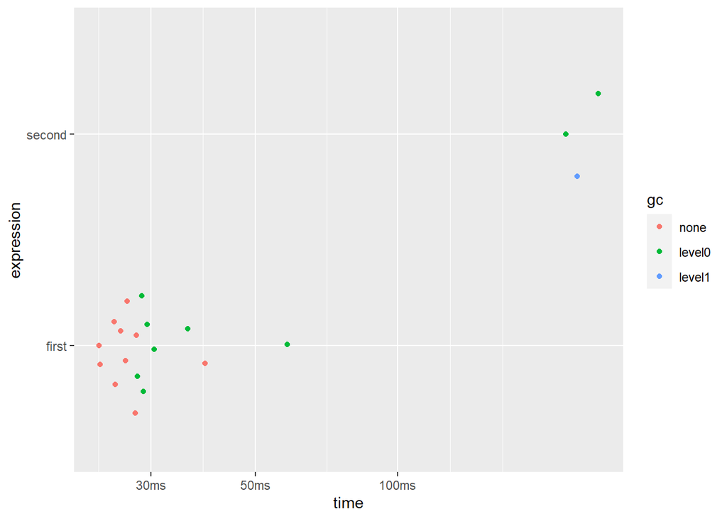

```r
show_bm=function(bm){
  print(bm)
  autoplot(bm)
}

bench::mark(
  check=F,
  first=linear_gd_optim(b_pre,X,y),
  second=linear_gd_optim2(b_pre,X,y)
)%>% show_bm()
```

The first version is clearly faster than the second one. Consider now the Steepest descent method

```r
basic_sd(b_pre,X,y,tol=tol,maxit=maxit)
```

```
## $param
##         [,1]
##    0.9847794
## x1 0.4867891
## x2 0.2175172
##
## $iter
## [1] 20
```

Let us compare the Gradient Descent and the Steepest Descent:

```r
bench::mark(
  check=F,
  GD=linear_gd_optim(b_pre,X,y),
  SD=basic_sd(b_pre,X,y)
)%>% show_bm()
```

```
## # A tibble: 2 x 13
##   expression     min  median `itr/sec` mem_alloc `gc/sec` n_itr  n_gc total_time
##   <bch:expr> <bch:t> <bch:t>     <dbl> <bch:byt>    <dbl> <int> <dbl>   <bch:tm>
## 1 GD          21.8ms  22.6ms      42.7    19.6MB    28.4     12     8      281ms
## 2 SD         208.7us 225.7us    4095.       47KB     4.11  1991     2      486ms
## # ... with 4 more variables: result <list>, memory <list>, time <list>,
## #   gc <list>
```

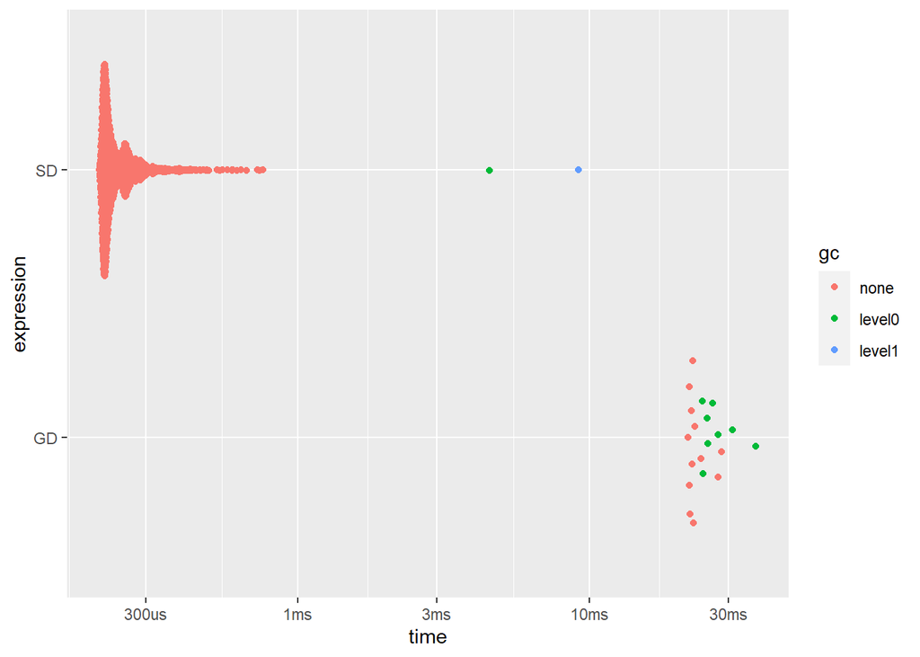

As it can be observed, the steepest descent algorithm is much faster than the gradient descent. The main reason is that the choice of the stepsize of the steepest descent algorithm (which depends on the Hessian) makes it perform less iterations.

## Leave-one-out cross validation

This are two examples of usage of the functions `cm_LOOCV` and `cm_pllLOOCV`. Both functions allow a simple computation of the mean squared error of prediction arising from a linear regression (whose parameters are computed through a Steepest descent method) through LOOCV, a well known resampling method. The first function perform a sequential LOOCV, while the second one allows for some parallelization that may speed up computation.

As a first example, let’s consider the usual dataset:

```r
library(gradescCM)
set.seed(8675309)
n = 1000
x1 = rnorm(n)
x2 = rnorm(n)
y = 1 + .5*x1 + .2*x2 + rnorm(n)
X=cbind(x1,x2)
```

We set the initial values for the parameters’ vector beta, together with the tolerance and maximum number of iterations:

```r
b_pre=c(0,0,0)
tol=1e-3
maxit=10^3
```

For the first function we have

```r
cm_LOOCV(y = y, X = X, b_pre = b_pre, tol = tol, maxit = maxit)
```

```
## [1] 1.063602
```

For the second function

```r
cm_pllLOOCV(y = y, X = X, b_pre = b_pre, tol = tol, maxit = maxit)
```

```
##          [,1]
## [1,] 1.063602
```

We can compare their efficiency as usual

```r
bench::mark(
  check=F,
  sequential=cm_LOOCV(y, X, b_pre = b_pre, tol = tol, maxit = maxit),
  parallel=cm_pllLOOCV(y, X, b_pre = b_pre, tol = tol, maxit = maxit)
)%>% show_bm()
```

```
## # A tibble: 2 x 13
##   expression      min   median `itr/sec` mem_alloc `gc/sec` n_itr  n_gc
##   <bch:expr> <bch:tm> <bch:tm>     <dbl> <bch:byt>    <dbl> <int> <dbl>
## 1 sequential 290.99ms 291.22ms     3.43       92MB     8.58     2     5
## 2 parallel      2.65s    2.65s     0.377    83.8MB     1.13     1     3
## # ... with 5 more variables: total_time <bch:tm>, result <list>, memory <list>,
## #   time <list>, gc <list>
```

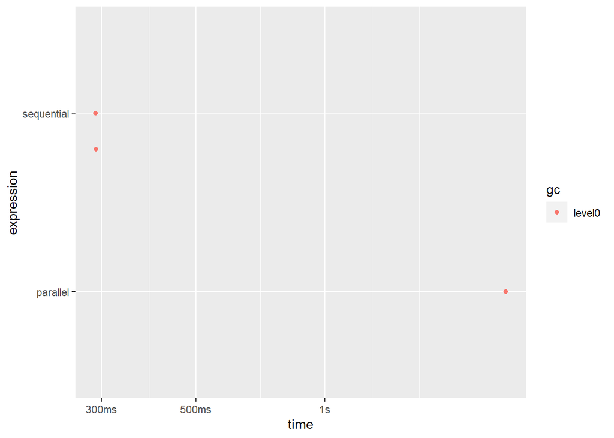

```r
set.seed(8675309)
n = 2*10^4
x1 = rnorm(n)
x2 = rnorm(n)
y = 1 + .5*x1 + .2*x2 + rnorm(n)
X=cbind(x1,x2)
options(warn=-1)
```

Again, we set the initial values for the parameters’ vector beta, together with the tolerance and maximum number of iterations:

```r
b_pre=c(0,0,0)
tol=1e-3
maxit=10^3
```

We have

```r
cm_LOOCV(y = y, X = X, b_pre = b_pre, tol = tol, maxit = maxit)
```

```
## [1] 1.006506
```

```r
cm_pllLOOCV(y = y, X = X, b_pre = b_pre, tol = tol, maxit = maxit)
```

```
##          [,1]
## [1,] 1.006506
```

And again we compare the efficiency of the two algorithms

```r
bench::mark(
  check=F,
  sequential=cm_LOOCV(y, X, b_pre = b_pre, tol = tol, maxit = maxit),
  parallel=cm_pllLOOCV(y, X, b_pre = b_pre, tol = tol, maxit = maxit)
) %>% show_bm()
```

```
## # A tibble: 2 x 13
##   expression   min median `itr/sec` mem_alloc `gc/sec` n_itr  n_gc total_time
##   <bch:expr> <bch> <bch:>     <dbl> <bch:byt>    <dbl> <int> <dbl>   <bch:tm>
## 1 sequential    1m     1m    0.0166    35.8GB    5.50      1   331         1m
## 2 parallel   22.3s  22.3s    0.0448    28.9GB    0.627     1    14      22.3s
## # ... with 4 more variables: result <list>, memory <list>, time <list>,
## #   gc <list>
```

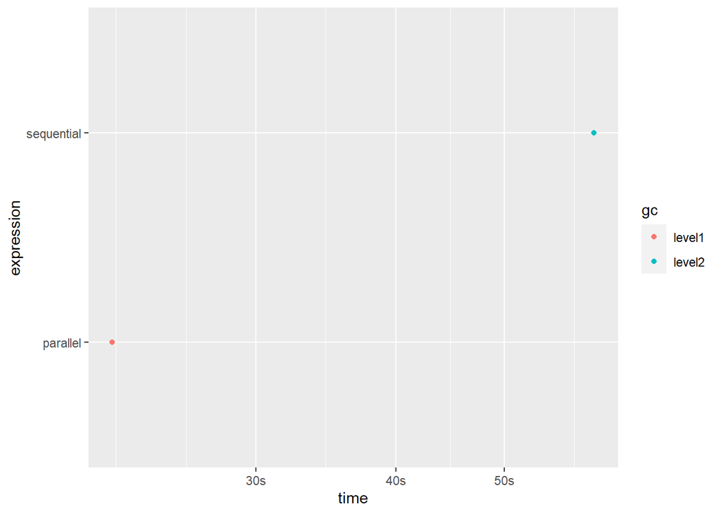

As it can be observed, in the first example, the sequential version of LOOCV is more efficient than the parallelized one and viceversa in the second one. Hence, parallelizing the algorithm is not always computationally convenient, as for small dataset the cost of setting up the parallelization may be higher than the gain in efficiency. Clearly the more computationally intensive the problem at hand is, the more the advantages of using parallelization.